# VedatMilor

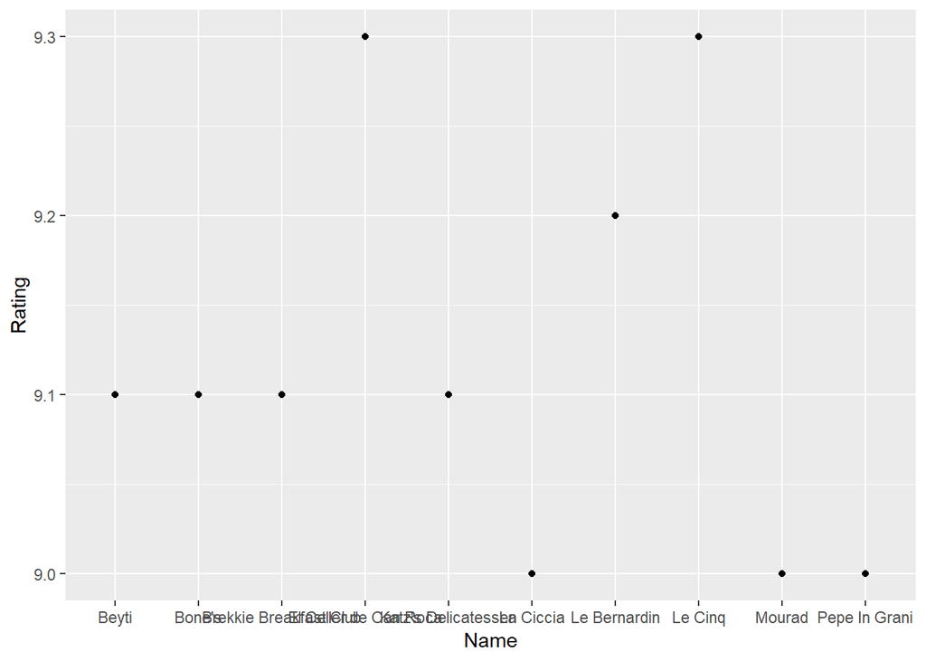

```r
 ggplot(data=topTen,aes(x= Name, y= Rating))+
  geom_point(stat="identity")
```

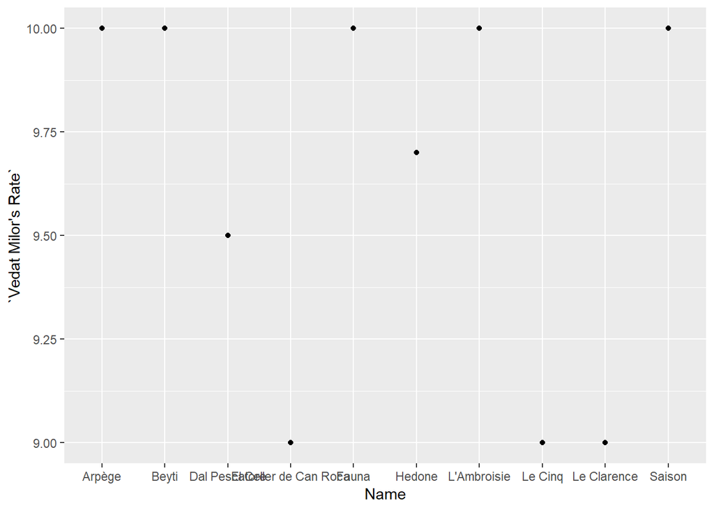

```r
 ggplot(data=topTenofVM,aes(x= Name, y= `Vedat Milor's Rate`))+
  geom_point(stat="identity")
```

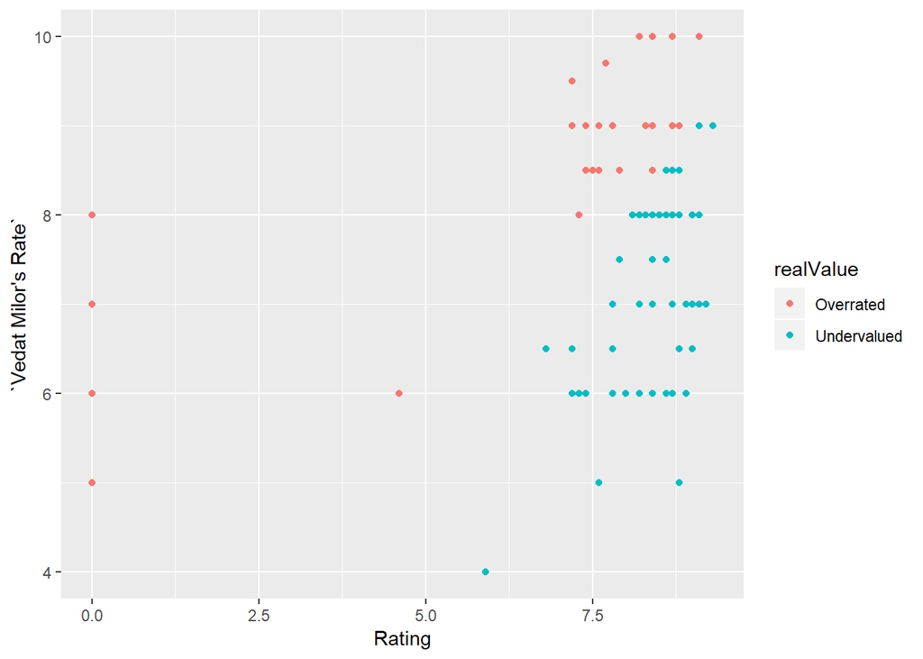

```r
raw_data %>%
  mutate(realValue = ifelse(Rating<`Vedat Milor's Rate`,"Overrated","Undervalued")) %>% ggplot() +
  geom_point(aes(x =Rating, y= `Vedat Milor's Rate`, color = realValue))
```

As we mentioned before there can be different factors on these rates so it is not proper to say Vedat Milor overrated this restaurants or not. However, in this project with our limited data we can easily say it.Number of undervalued restaurant are higer than the overrated, we can easily think the reason can be Vedat Milor is a gourmet and his taste is more sensitive etc.